# Final

2020209

2023-12-06

```r
library(tidyverse)
```

```r
library(ggplot2)
library(dplyr)
library(vip)
library(caret)
library(ranger)
library(yardstick)
library(Matrix)
library(lme4)

setwd("/Users/tomfeeney/Documents/data ")
wines= read_csv("wines.csv")
```

**Exploration and Viz**

# **1.1 What is your best guess about the price and rating of wines from each country?**

**Prices by country**

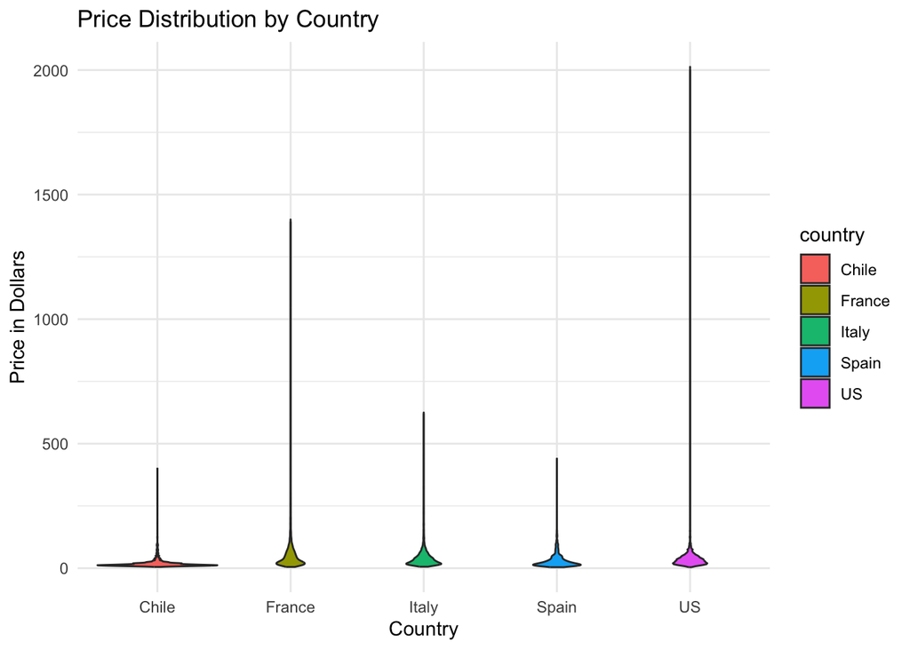

```r
# Violin plot with ggplot2
Country_price = ggplot(wines, aes(x = country, y = price, fill = country)) +
  geom_violin() +
  labs(x = 'Country', y = 'Price in Dollars', title = 'Price Distribution by Country') +
  theme_minimal()
Country_price
```

```r
# this is difficult to see how expensive each wine; the data is skewed so lets use median rather than mean.

# Ordering the data by means.
med_prices = aggregate(price ~ country, data = wines, FUN = median)
med_prices
```

```
##   country price
## 1   Chile    14
## 2  France    35
## 3   Italy    30
## 4   Spain    20
## 5      US    30
```

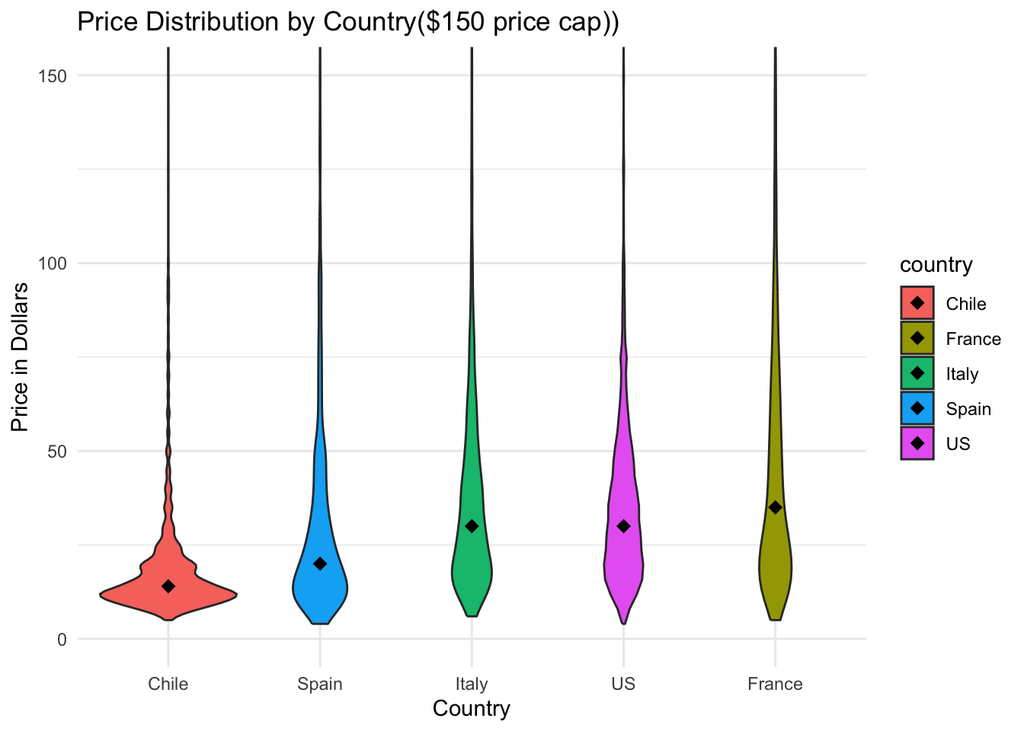

```r
ordered_countries_med = med_prices[order(med_prices$price), "country"]

# Create a violin plot with cropped y-axis and ordered countries;
# Add mean points
Country_price_ordered_cropped_med = ggplot(wines, aes(x = factor(country, levels = ordered_countries_med), y = price, fill = country)) +
  geom_violin() +
  geom_point(aes(x = factor(country, levels = ordered_countries_med), y = price),
             stat = 'summary', fun = 'median', shape = 18, color = 'black', size = 3) +
  coord_cartesian(ylim = c(0, 150)) +  # Crop y-axis to a maximum of 100
  labs(x = 'Country', y = 'Price in Dollars', title = 'Price Distribution by Country($150 price cap))') +
  theme_minimal()
Country_price_ordered_cropped_med
```

A violin plot of wine prices by countries shows that the distribution of prices differ, they all have long and thin tails which show there are some but not many really expensive wines (with the US, France and Italy all having wines more expensive than $500). This is useful for seeing where has the most expensive wines, but is less useful for seeing the distribution of each wine, I have cut out wines which are more than $150 in another plot and the distribution of wine prices for each country is clearer to see. The positive skew to the distribution of data means that median will give the best representation of the average price of wine.

There is positive skew in this data where, the few expensive wines from each country push the mean price higher. The median is less effected by this positive skew (the mean) so will give a better indication of central tendency in this case .

| **Country** | **Mean Price** | **Median Price** |
| --- | --- | --- |
| France | 55.04484 | 35 |
| Italy | 42.46049 | 30 |
| US | 36.48090 | 30 |
| Spain | 30.42872 | 20 |
| Chile | 19.17942 | 14 |

French wines are the most expensive, on average costing $35, the $20 difference between the mean and median suggests that there are some (but not many) very expensive wines which are skewing the mean.

Italian and US wines are the next expensive, with a median of $30.

Spanish wine costs $20, and Chilean wine costs $14 on average predicted by the median.

**Scores by** **Country**

```r
# Ordering the data by means.
mean_points = aggregate(points ~ country, data = wines, FUN = mean)
mean_points
```

```
##   country   points
## 1   Chile 86.21787
## 2  France 88.84237
## 3   Italy 88.94056
## 4   Spain 86.86924
## 5      US 88.12921
```

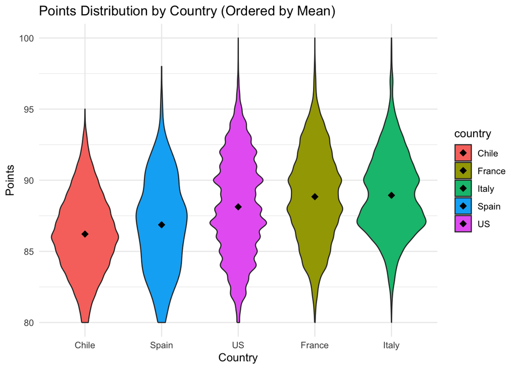

| **Country** | **Points** |
| --- | --- |
| Chile | 86.21787 |
| Spain | 86.86924 |
| US | 88.12921 |
| France | 88.84237 |
| Italy | 88.94056 |

```r
ordered_countries_points = mean_points[order(mean_points$points), "country"]

# Create a violin plot with ordered countries;
# Add mean points for points
Country_points_ordered = ggplot(wines, aes(x = factor(country, levels = ordered_countries_points), y = points, fill = country)) +
  geom_violin() +
  geom_point(aes(x = factor(country, levels = ordered_countries_points), y = points),
             stat = 'summary', fun = 'mean', shape = 18, color = 'black', size = 3) +
  labs(x = 'Country', y = 'Points', title = 'Points Distribution by Country (Ordered by Mean)') +
  theme_minimal()
Country_points_ordered
```

The violin plot shows that there is no obvious skew, therefore mean will be the best estimate for average wine score for each country.

The mean values suggest on average that Italian wine score the highest points with 88.9, this is followed by French wine which scores 88.8 points, then by US, with 88.1. On average Chilean wine scores the lowest (86.2) but is only just with Spanish wine scoring 86.9.

**These averages suggest that French wine is the most expensive and scores second highest scorer.**

# **1.2 Is this data frame tidy? Why or why not? Make sure to use the three rules of tidy data to justify your answer. If you can, tell me the “tidy” form for this data, and in what situations we might prefer the “tidy” or “messy” form.**

This data frame is not tidy, it is wide as there is more than one variable represented in the columns.

For the first column, the variety variable is tidy, the is one variable for the column (rule 1) and there is one value in each cell (rule 3).

But when we look at the rest of the columns the count and country, or rating and country are included in the headings meaning that there is more than one variable for each column. This violates rule 1 that every variable is a column. Meaning the data isn’t tidy.

The pivot_longer function could be used to make this data set tidy. The first four observations of the tidy data would look like this:

| Variety | Country | Count | Rating |
| --- | --- | --- | --- |
| Cabernet Sauvignon | Chile | 719 | 86 |
| Cabernet Sauvignon | France | 31 | 84 |
| Cabernet Sauvignon | Italy | 123 | 90 |
| Cabernet Sauvignon | Spain | 47 | 86 |

The tidy form is the same data, in a different layout. Many packages in R (in the tidyverse) will only work with tidy data. A consistent, tidy data form allows us to have an underlying uniformity in the data which can make it much easier to work with (mainly when switching between different models you can change the type you are looking to analyse very quickly). In this case the tidy data is more easy to run functions in the tidyverse such as ggplot which make visualising the data consistent.

The downside of tidy data, as demonstrated in the table above is that it can make the data less compact and less storage efficient. A value that previously represented the score for a county in one cell now takes two with an extra row being required. The condensed ‘messy’ form allows the same amount of information to be conveyed without spreading it out. If only interested in the summary of the data (with more simple statistics) it may just be easier to keep it ‘messy’ as making the data tidy adds an additional step to the process which in some cases is unnecessary.

The messy form has efficiency advantages for simple statistics, the tidy form makes more complex functions more easy to work with.

# **1.3 *Challenge* What `variety` of wine has the highest median `points` in each country? Can you make a plot that shows this information?**

```r
min(wines$points)
```

```
## [1] 80
```

```r
median_points = wines %>%
  group_by(country, variety) %>%
  summarise(median_points = median(points, na.rm = TRUE))
```

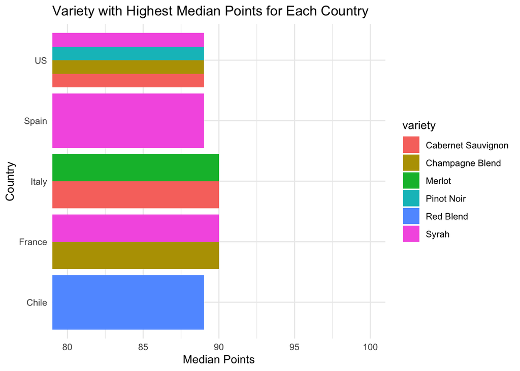

```r
top_variety = median_points %>%
  group_by(country) %>%
  top_n(1, wt = median_points)


top_var_country = ggplot(top_variety, aes(x = median_points, y = country, fill = variety)) +
  geom_bar(stat = "identity", position = "dodge") +
  coord_cartesian(xlim= c(80,100))+
  labs(title = "Variety with Highest Median Points for Each Country",
       x = "Median Points",
       y = "Country") +
  theme_minimal()

top_var_country
```

I have cropped the data as 80 is the minimum it can score, thus making the differences between countries easier to interpret.

Italy and France have the highest scoring varieties of wine (by the wine variety with highest median score). They each have two varieties of wine which on average (median) score 90 points. For Italy these are the Merlot and Cabernet Sauvignon, and for France it is the Syrah and Champagne Blend.

Chile and Spain are the only countries with a single variety with the highest median. For Chile the highest scoring wine by median is Red Blend. For Spain the highest is Syrah.

The US has 4 with equal medians, with Syrah, Pinot Noir, Champagne Blend and Cabernet Sauvignon all scoring as the top variety in the country.

# **2.1 Does this decision tree provide evidence that French wine is overpriced? Why or why not?**

The decision tree is provided with variety, country, points and review sentiment variables to find what’s influencing the prices of wine. It finds that points and country are the variables most useful in separating wines into groups of similar prices.

There is no evidence from the decision tree that wine prices for those which score lower than 92 points are influenced by whether or not its French. Within this (lower scoring) branch of the tree, the only factor influencing the grouping of prices is another score split. Therefore the tree is unable to provide evidence towards lower scoring french wines being overpriced (more expensive for the same quality).

The decision tree lacks the ability to include factors it hasn’t seen. For example, how long a wine has aged for which may have an influence on the price charged for wine as the cost of producing it will be higher but it may not be met by an increase in quality (points scored). If French wines are more expensive to produce, due to being aged longer than other wines, while not having an increase in quality, this may be one explanation for the price discrepancy between french and other wines of similar quality. It would be expected however for this influence to make French wines ‘better’ or worth a higher price to be included in their score of quality. The decision tree is providing evidence for French wine being overpriced from the variables it has seen, but it is not able to account for other potential variables.

The decision tree finds that country and score are the key factors defining price. Generally, whether or not a wine is French is only influential on price when it scores highly. When French wines are compared to other wines of similar high quality (scoring above 92), they are nearly twice the price demonstrating they are more expensive at similar qualities and thus are overpriced.

# **2.2 Fit a linear model using `points`, `country`, and `review_sentiment` to predict `price` of a wine. What does this model tell you about the relationship between price and its predictors? Which predictors are *significant*? Which predictors are *practically important*?**

```r
# fitting initial model
lm_1= lm(price~ points + country + review_sentiment, data=wines)
summary(lm_1)
```

```
##
## Call:
## lm(formula = price ~ points + country + review_sentiment, data = wines)
##
## Residuals:
##     Min      1Q  Median      3Q     Max
##  -69.84  -14.99   -4.15    7.94 1957.85
##
## Coefficients:
##                    Estimate Std. Error t value Pr(>|t|)
## (Intercept)      -441.88756    4.52262 -97.706  < 2e-16 ***
## points              5.38800    0.05264 102.355  < 2e-16 ***
## countryFrance      22.63277    0.77640  29.151  < 2e-16 ***
## countryItaly        8.99849    0.87231  10.316  < 2e-16 ***
## countrySpain        7.63833    1.22140   6.254 4.05e-10 ***
## countryUS           7.60803    0.65315  11.648  < 2e-16 ***
## review_sentiment   -6.80271    0.33545 -20.280  < 2e-16 ***
## ---
## Signif. codes:  0 '***' 0.001 '**' 0.01 '*' 0.05 '.' 0.1 ' ' 1
##
## Residual standard error: 32.2 on 38676 degrees of freedom
## Multiple R-squared:  0.2556, Adjusted R-squared:  0.2555
## F-statistic:  2213 on 6 and 38676 DF,  p-value: < 2.2e-16
```

```r
# Feature importance.
# this computes which are the most important features based on the average
# decrease in r squared

vi_permute(
  object = lm_1,
  target = "price",
  feature_names = c("points", "country", "review_sentiment"),
  train = wines,
  metric="rsq",
  nsim = 10,
  pred_wrapper = predict)
```

```
## # A tibble: 3 × 3
##   Variable         Importance    StDev
##   <chr>                 <dbl>    <dbl>
## 1 points               0.254  0.000474
## 2 country              0.0441 0.00121
## 3 review_sentiment     0.0156 0.000507
```

The linear model fits a linear relationship between the variables and price. The model finds that all of the variables are statistically significant in their influence on price to a 99.9% confidence interval.

Generally, as the wine scores higher it prices higher. This initial linear model predicts that for each point increase in score of a wine, its price will rise by $5.38

It finds that relative to Chilean wine, all other countries have a higher price. If the wine is French rather than Chilean is expected cost $22.63 more. This is a larger difference than the rest of the countries; for Italy its $8.99, for Spain $7.64 and for the US $7.61 (each as an expected price increase relative to Chile).

Review sentiment is also influential on the price. If a wine scores 1 unit of review sentiment higher its price is expected to decrease by $6.80. This seems odd. We would expect a more favorable review to be linked to a more expensive wine but that may just expose one of the limitations of this initial model.

The linear model finds score is the key factor in the price of a wine, followed by the country: higher scoring wines are more expensive. The linear model also finds that French wines are the most expensive.

# 2.3 *Challenge* **Critique your model from the previous question. What does it do well? Are its predictions biased for certain types of observations? Are there any predictors you think should be included? Improve your model if you find a better specification.**

Overall model residuals

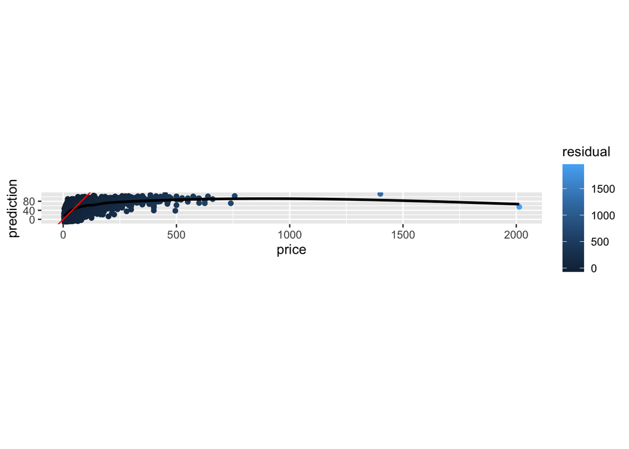

```r
# Model vs residuals plot
wines |> mutate(
  prediction = predict(lm_1),
  residual = resid(lm_1)
  ) |>
ggplot(aes(x=price, y=prediction, color=residual)) +
  geom_point() + geom_smooth(color='black', se=F) +
  geom_abline(color='red', slope=1, intercept=0) +
  coord_equal()
```

**Error by predictor**

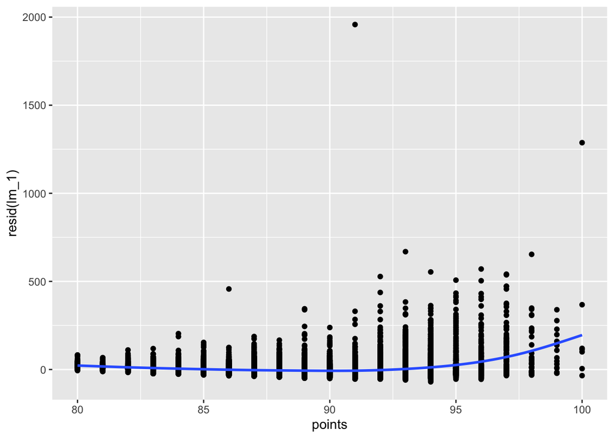

```r
# Points
ggplot(wines, aes(x=points, y=resid(lm_1))) +
    geom_point() + geom_smooth(se=F)
```

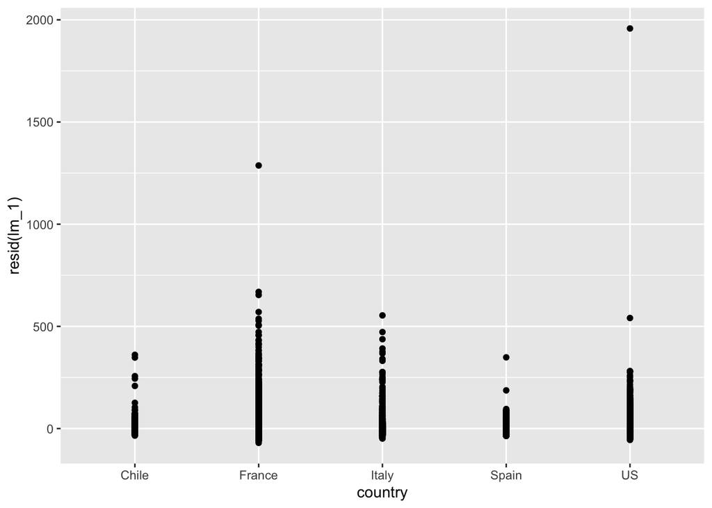

```r
# Country
ggplot(wines, aes(x=country, y=resid(lm_1))) +
    geom_point() + geom_smooth(se=F)
```

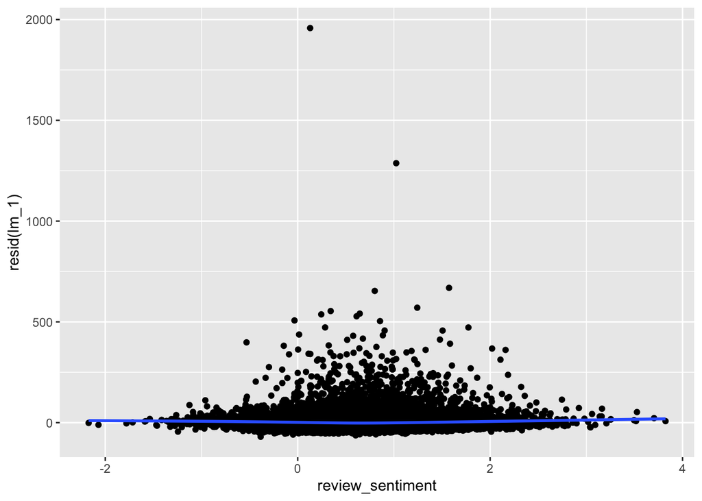

```r
# Review sentiment
ggplot(wines, aes(x=review_sentiment, y=resid(lm_1))) +
    geom_point() + geom_smooth(se=F)
```

Additionally, when investigating the residual error of each of these predictor variables, there are some visable patterns. Ideally the residual error would not have patterns as it indicates that the model is not accounting for an additional influence on the price of wine.

When investigating the residual error by points, the model does an alright job, before under predicting price above a score of 95. There is under prediction bias by points.

Generally, the model also under predicts price when it comes to splitting the data by country. French price prediction appear to have more under prediction bias in them than others.

Review sentiment also shows some shape in the residuals. Reviews between 0 and 2 appear to have a bell shape in their under predictions.

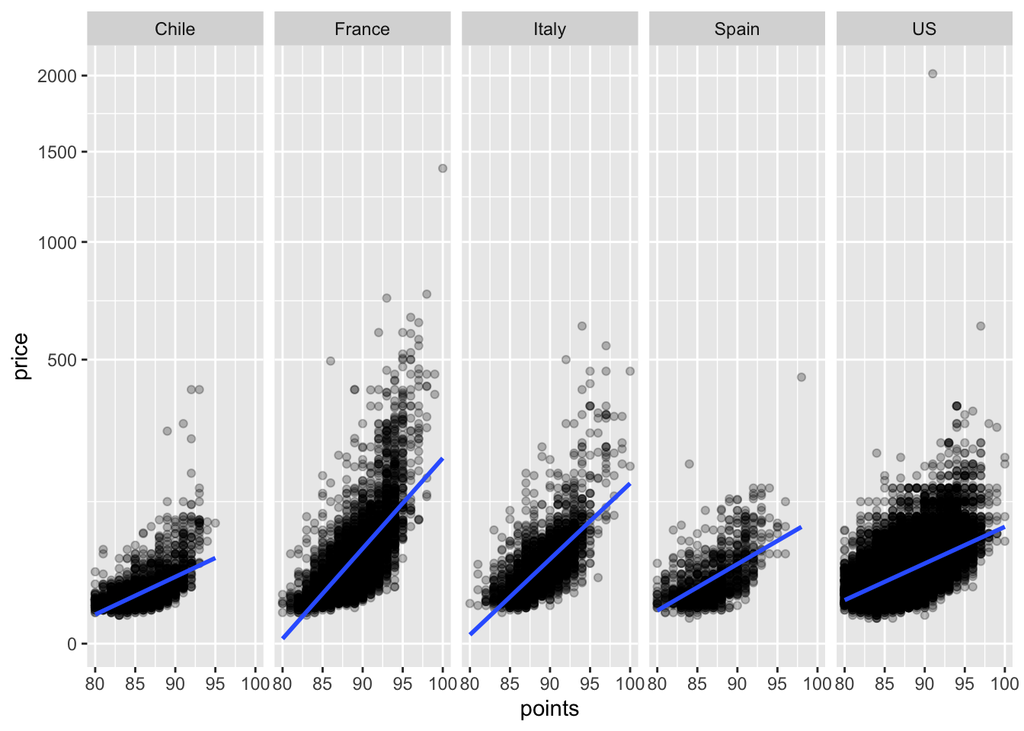

```r
ggplot(wines, aes(x=points, y=price)) +
  geom_point(alpha=.25, lwd=0) +
  geom_smooth(method=lm, se=F,) +
  facet_grid(~country) +
  scale_y_sqrt()
```

When assessing the bias for price by score by country, there is bias that shows French and Italian wine prices are more influenced by score.

For this reason I chose to add the interaction of points and country to improve the initial linear model.

**Improving the linear model**

```r
# testing different interactions
summary(lm_1)
```

```
##
## Call:
## lm(formula = price ~ points + country + review_sentiment, data = wines)
##
## Residuals:
##     Min      1Q  Median      3Q     Max
##  -69.84  -14.99   -4.15    7.94 1957.85
##
## Coefficients:
##                    Estimate Std. Error t value Pr(>|t|)
## (Intercept)      -441.88756    4.52262 -97.706  < 2e-16 ***
## points              5.38800    0.05264 102.355  < 2e-16 ***
## countryFrance      22.63277    0.77640  29.151  < 2e-16 ***
## countryItaly        8.99849    0.87231  10.316  < 2e-16 ***
## countrySpain        7.63833    1.22140   6.254 4.05e-10 ***
## countryUS           7.60803    0.65315  11.648  < 2e-16 ***
## review_sentiment   -6.80271    0.33545 -20.280  < 2e-16 ***
## ---
## Signif. codes:  0 '***' 0.001 '**' 0.01 '*' 0.05 '.' 0.1 ' ' 1
##
## Residual standard error: 32.2 on 38676 degrees of freedom
## Multiple R-squared:  0.2556, Adjusted R-squared:  0.2555
## F-statistic:  2213 on 6 and 38676 DF,  p-value: < 2.2e-16
```

```r
# r sq 0.255

Imp_lm= lm(price~ country*points + variety , data= wines )
summary (Imp_lm)
```

```
##
## Call:
## lm(formula = price ~ country * points + variety, data = wines)
##
## Residuals:
##     Min      1Q  Median      3Q     Max
##  -98.78  -12.92   -3.09    7.68 1973.31
##
## Coefficients:
##                         Estimate Std. Error t value Pr(>|t|)
## (Intercept)            -224.1825    18.2489 -12.285  < 2e-16 ***
## countryFrance          -765.7333    21.8290 -35.079  < 2e-16 ***
## countryItaly           -530.7961    25.2818 -20.995  < 2e-16 ***
## countrySpain            -95.1055    31.7456  -2.996 0.002738 **
## countryUS               -19.3125    18.8095  -1.027 0.304549
## points                    2.9613     0.2114  14.006  < 2e-16 ***
## varietyChampagne Blend   -3.1896     1.3334  -2.392 0.016760 *
## varietyChardonnay       -16.4499     0.5120 -32.126  < 2e-16 ***
## varietyMerlot           -13.2401     0.6764 -19.574  < 2e-16 ***
## varietyPinot Noir        -6.5058     0.4987 -13.047  < 2e-16 ***
## varietyRed Blend        -12.8797     0.6298 -20.450  < 2e-16 ***
## varietyRosé             -29.3551     0.9094 -32.281  < 2e-16 ***
## varietySauvignon Blanc  -23.6248     0.6849 -34.494  < 2e-16 ***
## varietySyrah            -13.6005     0.6325 -21.502  < 2e-16 ***
## countryFrance:points      8.9704     0.2509  35.746  < 2e-16 ***
## countryItaly:points       6.1532     0.2886  21.322  < 2e-16 ***
## countrySpain:points       1.2306     0.3661   3.361 0.000777 ***
## countryUS:points          0.3314     0.2178   1.521 0.128165
## ---
## Signif. codes:  0 '***' 0.001 '**' 0.01 '*' 0.05 '.' 0.1 ' ' 1
##
## Residual standard error: 29.91 on 38665 degrees of freedom
## Multiple R-squared:  0.3578, Adjusted R-squared:  0.3575
## F-statistic:  1267 on 17 and 38665 DF,  p-value: < 2.2e-16
```

```r
# r sq 0.36

# the R squared of the improved model is higher.

#logging the data didnt make enough of a difference to do it here


# cross validation


# train test split
# set a seed so that the data is random but it is the same each time

library(caret)
library(yardstick)

set.seed(2023)
wine_train= wines |> slice_sample(prop=0.75)
wine_test= wines |> filter(!description %in% wine_train$description)

lm_1_train= lm(price~ points + country + review_sentiment, data=wine_train)

pred_train_1= predict(lm_1_train)
pred_test_1=predict(lm_1_train, newdata= wine_test)

resid_train= residuals(lm_1_train)
resid_test= wine_test$price - pred_test_1



# comparing to the improved model
lm_2_train= lm(price~ country*points + variety , data= wine_train)

pred_train_2= predict(lm_2_train)
pred_test_2=predict(lm_2_train, newdata= wine_test)

resid_train_2= residuals(lm_2_train)
resid_test_2= wine_test$price - pred_test_2


#RMSE in and out of sample for each model

in_sample= rmse_vec(wine_train$price, pred_train_1)
in_sample
```

```
## [1] 30.79961
```

```r
# 30.79961

out_sample= rmse_vec(wine_test$price, pred_test_1)
out_sample
```

```
## [1] 36.01715
```

```r
# 36.01715


in_sample_2= rmse_vec(wine_train$price, pred_train_2)
in_sample_2
```

```
## [1] 28.22641
```

```r
# old model 30.79961
# new model 28.22

out_sample_2= rmse_vec(wine_test$price, pred_test_2)
out_sample_2
```

```
## [1] 34.43717
```

```r
# old model 36.01715
# new model 34.437
```

| Model | In sample error | Out of sample error |
| --- | --- | --- |
| InItial | 30.8 | 36.0 |
| Improved | 28.2 | 34.4 |

The predictive ability of the linear model is improved by including the interaction effect of country and points. This indicates that the interaction between these two variables is important in the price of wine. A high scoring french wine is likely to be a lot more expensive than a low scoring Chilean one.

In sample error indicates how well the model is able to fit to data it has seen. The improved model is $2.60 more accurate for the random seed I have chosen.

The out of sample error shows how general the model is, and demonstrates the predictive strength for data it hasn’t seen. As expected, the error is higher than the data it has seen but there is not a massive difference between the two suggesting that neither model is over fit. The improved model is $1.60 better at predicting prices for data it hasn’t seen for the specific split tested.

**Comparing residuals**

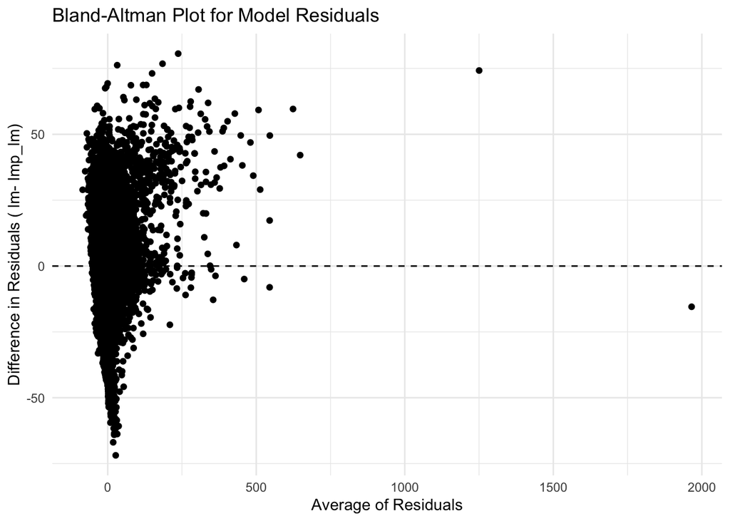

```r
residuals_lm <- residuals(lm_1)
residuals_imp_lm <- residuals(Imp_lm)

comparison_data <- data.frame(
  Points = wines$points,  # Replace with your independent variable
  Residuals_lm = residuals_lm,
  Residuals_imp_lm = residuals_imp_lm
)

comparison_data$Residual_Difference = comparison_data$Residuals_lm - comparison_data$Residuals_imp_lm
mean_residual_difference <- mean(comparison_data$Residual_Difference)



comparison_data$Mean_Residuals = (comparison_data$Residuals_lm + comparison_data$Residuals_imp_lm) / 2
ggplot(comparison_data, aes(x = Mean_Residuals, y = Residual_Difference)) +
  geom_point() +
  geom_hline(yintercept = 0, linetype = "dashed") +
  theme_minimal() +
  labs(title = "Bland-Altman Plot for Model Residuals",
       x = "Average of Residuals",
       y = "Difference in Residuals ( lm- Imp_lm)")
```

The Bland-Altman Plot allows us to compare the difference in residuals between the initial linear model and the improved model. The x axis shows the average of the residuals and the y axis indicates which model has smaller residuals. Points above the zero line are points where the residuals for the improved model are smaller, and between is where the initial model is smaller.

It appears that generally the residuals for the improved model are smaller as there are more points above the line than below it. This means that the difference between the predicted and the observed price is genrally lower for the improved model and thus it is an improvement.

**By country residual change**

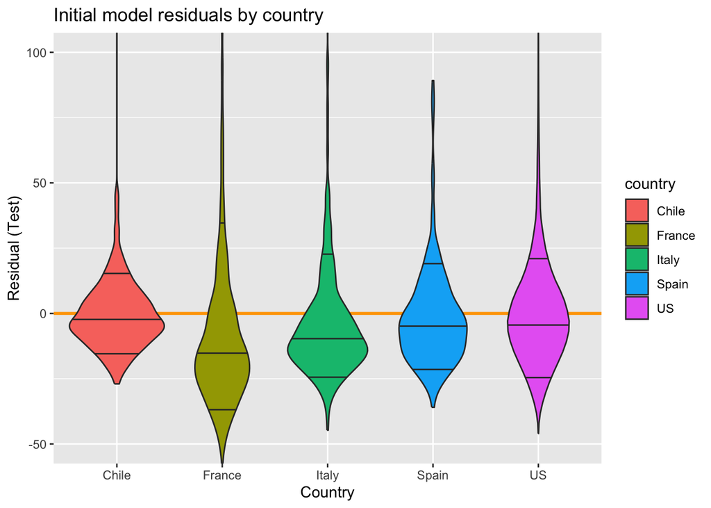

```r
# intial model out of sample error by country
ggplot(data=wine_test) +
geom_hline(yintercept=0, color='orange', lwd=1) +
   coord_cartesian(ylim= c(-50,100))+
geom_violin(aes(x=country, y=resid_test, fill=country),
draw_quantiles = c(.1,.5,.9)) +
labs(title= "Initial model residuals by country", x="Country", y="Residual (Test)")
```

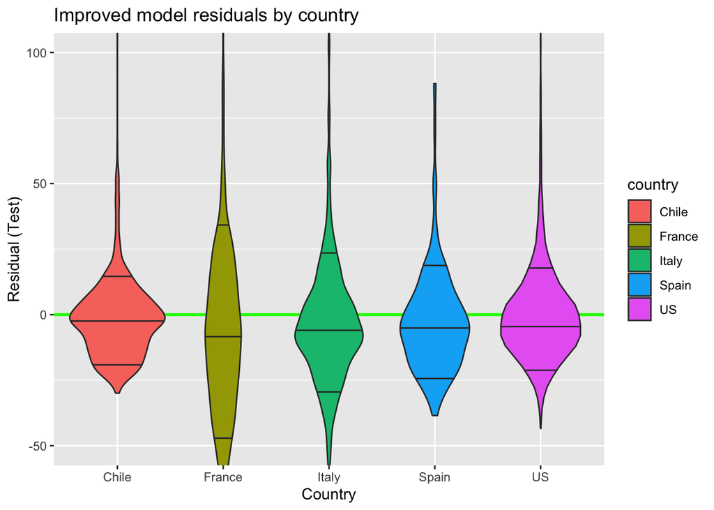

```r
# improved model out of sample error by country
ggplot(data=wine_test) +
geom_hline(yintercept=0, color='green', lwd=1) +
   coord_cartesian(ylim= c(-50,100))+
geom_violin(aes(x=country, y=resid_test_2, fill=country),
draw_quantiles = c(.1,.5,.9)) +
labs(title= "Improved model residuals by country",x="Country", y="Residual (Test)")
```

When comparing the model residuals between the improved and initial model by country, (specifically for the testing set of data neither model has seen), generally the improved model under predicts the price slightly less. The stretched nature of France in the improved models residuals shows that there is greater variability in the residuals. This is indicative that the model is better than the initial one for predicting all countries apart from France. This provides more evidence that the price of French wine is not driven by purely the variables the models have seen and instead there is something else influencing it. This is more evidence that French wine is overpriced.

The root mean squared error is lower for both the in and out of sample error in the improved model. This model accounts for the interaction between scores and country which improves its predictive accuracy.

The improved model does a better job at predicting the prices of wines for all countries other than for France, indicating that something other than the variables provided is influencing the price of French wine.

# **3.1 From first principles (that is, without fitting a model or considering residuals), which of the two models is likely to perform better on this data set to predict the price of wines? Why do you think this will work better than the alternative? K-nn or random forest?**

A random forest model will work better in this situation as the relationship between the variables and price is non linear (linear models are struggling with under prediction bias), there is a strong bias where price is consistently under predicted. Additionally K nn models may struggle with the curse of dimensionality because there are lots of dimensions.

One main issue with K nn models is that when there is a tie in the data, there is no way of differentiating which of the tie should be used, when there are categorical variables (in this case we have country and variety), there are lots of ties in the data, reducing the power of distance based prediction.

Regression forests are very powerful tools that can account for non linear relationships and interactions between features, and it is more robust to over fitting than K nn. Therefore as long as its not too computationally expensive the regression forest will be the better model for this situation.

# **3.2 Fit the model you chose in 3.1, and compare it to your best linear model from section 2. Which performs the best in terms of predictive accuracy? Do they agree about the important features or model biases?**

## **Fitting random forest model and testing its predictive accuracy**

```r
set.seed(2023)
wine_train= wines |> slice_sample(prop=0.75)
wine_test= wines |> filter(!description %in% wine_train$description)

rf= caret::train(price~points + country + variety + review_sentiment + wine_color, data= wines,
                method= 'ranger',
                trControl= trainControl(method = 'none'))


# how well does it predict
TT_rf= caret:: train(price~points + country + variety + review_sentiment + wine_color, data= wine_train,
                method= 'ranger',
                trControl= trainControl(method = 'none') )

in_sample_rf = rmse_vec(wine_train$price, predict(TT_rf, newdata= wine_train))
in_sample_rf
```

```
## [1] 22.9791
```

```r
out_sample_rf =rmse_vec(wine_test$price, predict(TT_rf, newdata= wine_test))
out_sample_rf
```

```
## [1] 32.75179
```

The Random Forest model demonstrates superior performance compared to the Improved Linear Model, as evidenced by its lower Root Mean Square Error (RMSE) scores. Specifically, the Random Forest model yields an in-sample error of $22.9 and an out-of-sample error of $32.8, both of which are notably lower than the respective errors of $28.2 and $34.4 from the Improved Linear Model.

| Model type | In sample error | out of sample error |
| --- | --- | --- |
| Initial linear model | 30.8 | 36.0 |
| Improved linear model | 28.2 | 34.4 |
| Random forest | 22.9 | 32.8 |

## **Comparing important features of linear model and random forest model**

```r
# improved linear model important features
 LM_important_features= vi_permute(
  object = Imp_lm,
  target = "price",
  feature_names = c("points", "country", "variety", "review_sentiment", "wine_color"),
  train = wines,
  metric="rsq",
  nsim = 10,
  pred_wrapper = predict)

 LM_important_features
```

```
## # A tibble: 5 × 3
##   Variable         Importance   StDev
##   <chr>                 <dbl>   <dbl>
## 1 points               0.337  0.00211
## 2 country              0.178  0.00394
## 3 variety              0.0801 0.00174
## 4 review_sentiment     0      0
## 5 wine_color           0      0
```

```r
# random forest important features
RF_important_features= vi_permute(
  object = rf,
  target = "price",
  feature_names = c("points", "country", "variety", "review_sentiment", "wine_color"),
  train = wines,
  metric="rsq",
  nsim = 10,
  pred_wrapper = predict)

RF_important_features
```

```
## # A tibble: 5 × 3
##   Variable         Importance   StDev
##   <chr>                 <dbl>   <dbl>
## 1 points               0.538  0.00471
## 2 country              0.314  0.0110
## 3 variety              0.129  0.00803
## 4 review_sentiment     0.0797 0.00144
## 5 wine_color           0.0499 0.00450
```

The linear model found that points(0.33) is the most important variable when considering price impact. This is followed by country (0.17) then variety (0.08).

Generally the random forest has better predictive accuracy and finds stronger relationships between wine price and the variables supplied, this is likely due to its ability to find non linear relationships and interactions between predictors.

# **4.1 Is French wine overpriced *in general*? That is, for similar wines of similar quality, do you generally pay more for them if they’re French?**

## Comparing score and price by groups and points

```r
# grouped prices

# Create a new variable for French wines
wines <- wines %>%
  mutate(Frenchness = ifelse(country == "France", "France", "Not France"))

# Create a new variable for score categories
wines$score_category <- cut(wines$points,
                            breaks = c(80, 85, 90, 95, Inf),
                            labels = c("80-85", "86-90", "91-95", "96+"),
                            include.lowest = TRUE)

# Calculate mean price for each combination of score category and Frenchness
mean_prices <- wines %>%
  group_by(score_category, Frenchness) %>%
  summarise(mean_price = mean(price, na.rm = TRUE))
```

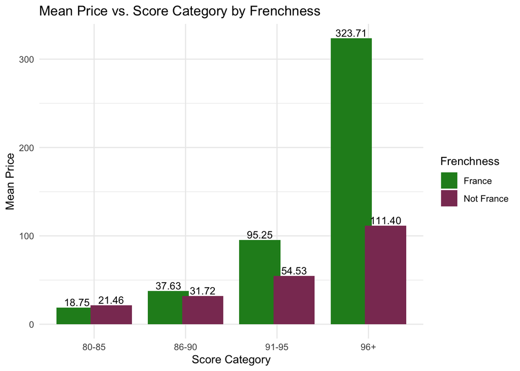

```r
# Grouped scores
ggplot(mean_prices, aes(x = score_category, y = mean_price, fill = Frenchness)) +
  geom_col(position = position_dodge(width = 0.75)) +
  geom_text(aes(label = sprintf("%.2f", mean_price)),
            position = position_dodge(width = 0.75),
            vjust = -0.25,  # Adjust if necessary to avoid overlap with the bars
            size = 3.5) +
  labs(x = "Score Category", y = "Mean Price", title = "Mean Price vs. Score Category by Frenchness") +
  scale_fill_manual(values = c("France" = "forestgreen", "Not France" = "hotpink4")) +
  theme_minimal()
```

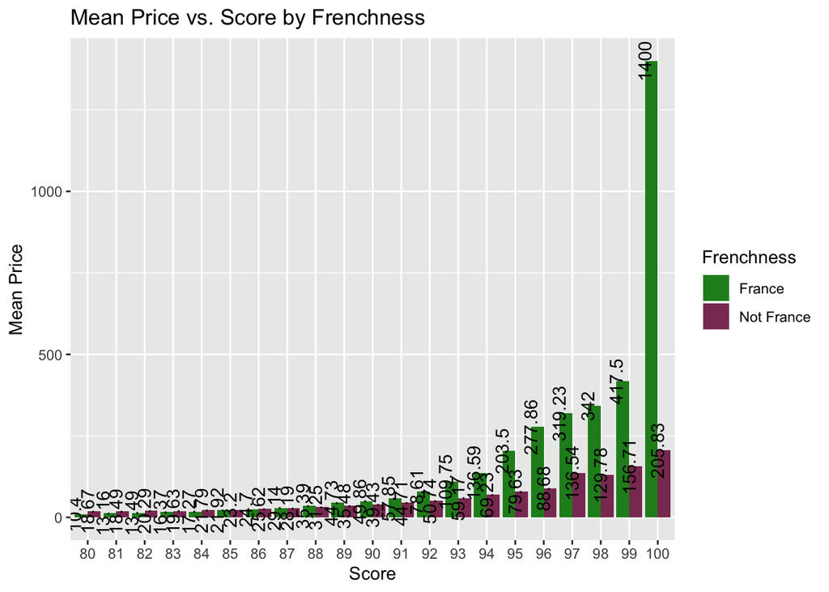

```r
# France has the strongest relationship between points and price


# Plotting by point
# Calculate mean price for each combination of score and Frenchness
mean_prices <- wines %>%
  group_by(points, Frenchness) %>%
  summarise(mean_price = mean(price, na.rm = TRUE))
# By score
ggplot(mean_prices, aes(x = as.factor(points), y = mean_price, fill = Frenchness)) +
  geom_col(position = "dodge") +
  geom_text(aes(label = round(mean_price, 2)),
            position = position_dodge(width = 0.9),
            angle= 90,
            vjust = 0, # Adjust this value as needed for better label positioning
            color = "black") +
  labs(x = "Score", y = "Mean Price") +
  ggtitle("Mean Price vs. Score by Frenchness") +
  scale_fill_manual(values = c("France" = "forestgreen", "Not France" = "hotpink4"))
```

The data set has two measures of quality, points and review_sentiment. I have chosen to use points as the measure of quality as the linear model and random forests found a much weaker influence on price from review sentiment.

Generally, higher scoring French wines are more expensive than wines from other countries of similar scores. This implies that high quality french wines are overpriced.

For example, when comparing a selection of wines which score between 91 and 95 points, a French one is expected to cost $95.25, while a wine from all other countries would be $54.53. This is substantial evidence to show that French wines are overpriced. The second bar plots show that as wines get higher points, the difference in price between French an other wines becomes more clear. Therefore the French wines are more overpriced, the higher quality they are.

## **Investigating further into this relationship for wine variety**

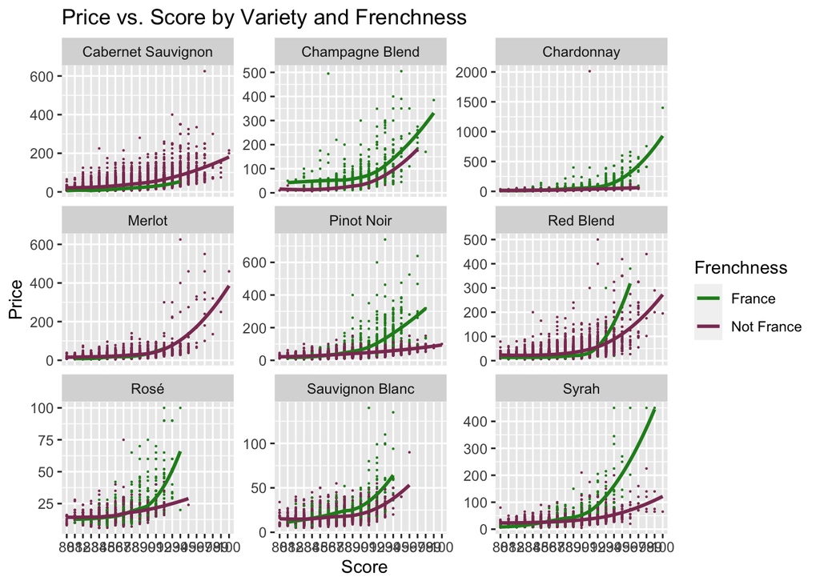

```r
# predicted wine prices in and out of france by variety

wines <- wines %>%
  mutate(Frenchness = ifelse(country == "France", "France", "Not France"))

# Plot the data using ggplot2 with facets for each variety
ggplot(wines, aes(x = as.factor(points), y = price, color = Frenchness)) +
  geom_point(size= 0.1) +
  geom_smooth(aes(group = Frenchness), method = "loess", se = FALSE) +  # Add linear trend lines
  labs(x = "Score", y = "Price") +
  ggtitle("Price vs. Score by Variety and Frenchness") +
  scale_color_manual(values = c("France" = "forestgreen", "Not France" = "hotpink4")) +
  facet_wrap(~variety, scales = "free_y", ncol = 3)
```

```r
# what proportion of each of these varieties are french?
variety_counts <- table(wines$variety)

# Calculate the number of French wines for each variety
french_counts <- table(wines$variety[wines$country == "France"])

# Calculate the proportion of French wines for each variety
proportions <- french_counts / variety_counts

# Create a data frame to store the results
result_df <- data.frame(Variety = names(variety_counts),
                        Total_Count = variety_counts,
                        French_Count = french_counts,
                        Proportion_French = proportions)

# Print or view the result
print(result_df)
```

```
##              Variety   Total_Count.Var1 Total_Count.Freq  French_Count.Var1
## 1 Cabernet Sauvignon Cabernet Sauvignon             6935 Cabernet Sauvignon
## 2    Champagne Blend    Champagne Blend              636    Champagne Blend
## 3         Chardonnay         Chardonnay             7470         Chardonnay
## 4             Merlot             Merlot             2807             Merlot
## 5         Pinot Noir         Pinot Noir             7929         Pinot Noir
## 6          Red Blend          Red Blend             5328          Red Blend
## 7               Rosé               Rosé             1483               Rosé
## 8    Sauvignon Blanc    Sauvignon Blanc             2769    Sauvignon Blanc
## 9              Syrah              Syrah             3326              Syrah
##   French_Count.Freq Proportion_French.Var1 Proportion_French.Freq
## 1                31     Cabernet Sauvignon            0.004470079
## 2               592        Champagne Blend            0.930817610
## 3              1536             Chardonnay            0.205622490
## 4                77                 Merlot            0.027431421
## 5              1074             Pinot Noir            0.135452138
## 6               169              Red Blend            0.031719219
## 7               787                   Rosé            0.530681052
## 8               499        Sauvignon Blanc            0.180209462
## 9               253                  Syrah            0.076067348
```

Across most wine varieties, the french wines are overpriced in the higher qualities and for the two wine varieties (Merlot and Cabernet Sauvignon) where this is not observed, the proportion french wines make of these data are very small. Champagne blend is overpriced across all points, and Sauvignon Blanc is overpriced at a lower points score of around 86. French Syrah’s have the strongest relationship between higher quality and being more overpriced. When looking in further detail, some varieties of French wine are cheaper, at the same quality of other countries. Generally by variety, French wines are not overpriced until higher points.

It is worth noting again that this is under the assumption that all factors dictating the price of a wine are included in the score factor. There could be a factor contributing to the quality of wine, or to the increased price of wine which is not accounted for in the point score. This could include how long a wine is aged for or the cultural factor which leads people to be more willing to pay more for a French wine than one from other countries. Points acts as a proxy for quality and may miss an element that some people deem as increasing the quality of the wine that wine mag may not include.

French wines are overpriced generally when they score higher than 92 points. Champagne Blends are overpriced across all scores, Syran have the strongest relationship between high scores and being overpriced. Due to a low sample size for Champagne Suavignon and Merlot, No conclusion can be made on whether or not these wines are overpriced if they are French.

# **4.2 *Challenge* Your friend and their uncle (famous actor/director Orson Welles) agree about French wines in general, but disagree about whether the US is almost as good as France at making *Champagne*. Your data’s `variety` column records the kind of grape(s) that made the wine—Champagne is usually as a `Champagne Blend`, so:**

## **Are French *Champagnes* overpriced relative to American ones?**

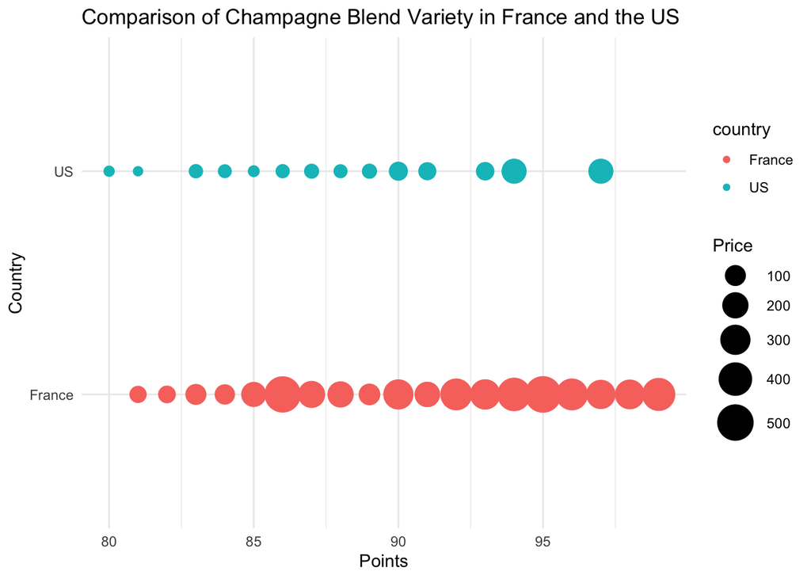

```r
filtered_data <- wines %>%
  filter(variety == "Champagne Blend" & (country == "France" | country == "US"))

# Plot the result using ggplot with scatter plot and labels
ggplot(filtered_data, aes(x = points, y = country, color = country, size = price)) +
  geom_point() +
  scale_size_continuous(range = c(2, 10)) +
  labs(title = "Comparison of Champagne Blend Variety in France and the US",
       x = "Points",
       y = "Country",
       size = "Price") +
  theme_minimal()
```

Exploration shows that generally the French wines are slightly higher rating in points than US. but the prices appear to be a lot higher.

To understand how similar in quality US and French wines are I will use a multi-level model to compare how different the quality of the two are relative to other countries Champagne blends.

# Champagne blend multi-level model

```r
# Filter the dataset for the Champagne Blend variety

champagne_data <- subset(wines, variety == "Champagne Blend")

mlm_champ_model <- lmer(points ~ country + (1 | country), data = champagne_data)

# Print the model summary

summary(mlm_champ_model)
```

```
## Linear mixed model fit by REML ['lmerMod']
## Formula: points ~ country + (1 | country)
##    Data: champagne_data
##
## REML criterion at convergence: 3197.6
##
## Scaled residuals:
##      Min       1Q   Median       3Q      Max
## -2.92648 -0.60945  0.05256  0.71457  3.03160
##
## Random effects:
##  Groups   Name        Variance Std.Dev.
##  country  (Intercept) 0.380    0.6164
##  Residual             9.127    3.0211
## Number of obs: 636, groups:  country, 5
##
## Fixed effects:
##               Estimate Std. Error t value
## (Intercept)     81.000      3.083  26.270
## countryFrance    8.841      3.147   2.810
## countryItaly     5.000      3.422   1.461
## countrySpain     5.000      4.361   1.147
## countryUS        7.324      3.183   2.301
##
## Correlation of Fixed Effects:
##             (Intr) cntryF cntryI cntryS
## countryFrnc -0.980
## countryItly -0.901  0.883
## countrySpan -0.707  0.693  0.637
## countryUS   -0.969  0.949  0.873  0.685
```

This MLM shows that when compared to the other countries, US Champagne blends are the closest in quality to French ones. The model suggests that French champagnes score, on average, 8.841 points higher than the baseline country, while US champagnes score 7.324 points higher than the baseline. The difference in points between French and US champagnes, when compared to the baseline, is relatively small (8.841 vs 7.324). This supports the friends theory that Us champagne is almost as good as French champagne.

So we know that US champagnes are almost as good as the french ones. Let’s investigate if US champagnes with similar points to the french ones are better value:

## Comparing French and Us price to points

```r
filtered_data <- wines %>%
  filter(variety == "Champagne Blend" & (country == "France" | country == "US"))

# Create a new variable for score categories
filtered_data$score_cat <- cut(filtered_data$points,
                                    breaks = c(80, 85, 90, 95, Inf),
                                    labels = c("80-85", "86-90", "91-95", "96+"),
                                    include.lowest = TRUE)

# Calculate mean price for each combination of score category, country, and variety
mean_prices_us_french <- filtered_data %>%
  group_by(score_cat, country, variety) %>%
  summarise(mean_prices_us_french = mean(price, na.rm = TRUE))
```

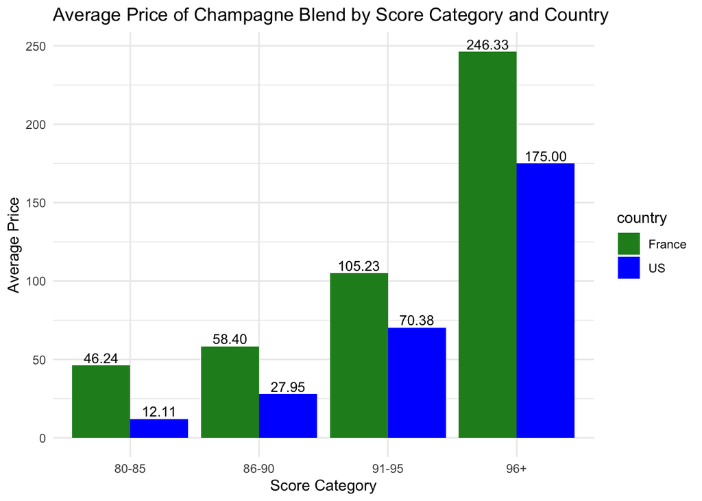

```r
ggplot(mean_prices_us_french, aes(x = score_cat, y = mean_prices_us_french, fill = country)) +
  geom_bar(stat = "identity", position = position_dodge()) +
  theme_minimal() +
  geom_text(aes(label = sprintf("%.2f", mean_prices_us_french)),
            position = position_dodge(width = 0.9),
            vjust = -0.25,
            size = 3.5) +
  xlab("Score Category") +
  ylab("Average Price") +
  ggtitle("Average Price of Champagne Blend by Score Category and Country") +
  scale_fill_manual(values = c("France" = "forestgreen", "US" = "blue"))
```

French Champagnes are more expensive than US Champagnes even when the score the wine receives is similar. This means that, the friend is right, US Champagnes are almost as good as french ones (when compared to the difference in score with other countries) and that French Champagnes are overpriced across all scores. For example in for wines which score between 80 and 85 points, a French Champagne on average costs $46.24 while a US one will cost $12.11.

# **4.3 *Challenge* In which country is the relationship between `points` and `review_sentiment` strongest? in which is it weakest? What does this tell you about potential bias in how *WineMag* judges talk about wines versus the scores they assign?**

## Plotting relationship between points and review sentiment by country

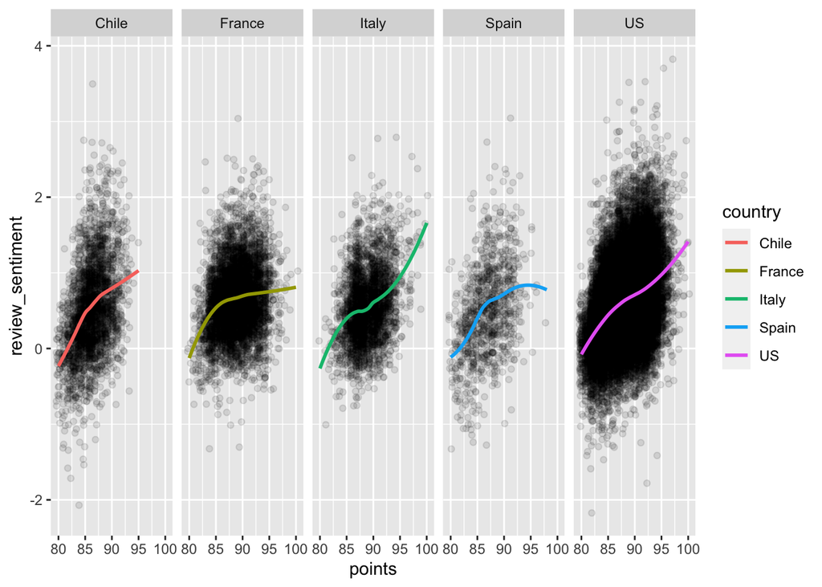

```r
# comparing relationships of review sentiment and points by country.
ggplot(wines, aes(x=points, y=review_sentiment, color=country)) +
  geom_point(aes(color=NULL), color='black', alpha=.1, position = 'jitter') +
  geom_smooth(method=loess, se=F) +
  facet_wrap(~country, ncol=5)
```

## Multi-level model of relationship

```r
# assessing how different they are:
mlm_points_rs = lmer(points ~ review_sentiment + (review_sentiment | country), data = wines)

summary(mlm_points_rs)
```

```
## Linear mixed model fit by REML ['lmerMod']
## Formula: points ~ review_sentiment + (review_sentiment | country)
##    Data: wines
##
## REML criterion at convergence: 197402
##
## Scaled residuals:
##     Min      1Q  Median      3Q     Max
## -3.0421 -0.7360 -0.0577  0.7181  3.7289
##
## Random effects:
##  Groups   Name             Variance Std.Dev. Corr
##  country  (Intercept)      1.4383   1.1993
##           review_sentiment 0.2112   0.4595   -0.40
##  Residual                  9.6214   3.1018
## Number of obs: 38683, groups:  country, 5
##
## Fixed effects:
##                  Estimate Std. Error t value
## (Intercept)       86.7307     0.5377 161.292
## review_sentiment   1.9101     0.2112   9.044
##
## Correlation of Fixed Effects:
##             (Intr)
## revw_sntmnt -0.396
```

This has the implication that the descriptions of French wines are not as strong as would be expected for their score. So french wines that score highly are not only overpriced, but also the reviews of them aren’t as positive as other similar scoring wines from different countries.